# Preprocessing with Principal Components Analysis (PCA)

Jeffrey Leek

Often you have multiple quantitative variables, and sometimes they’ll be highly correlated with each other. We’d like to include fewer variables that capture the relevant information.

## Correlated predictors

```r
library(caret); library(kernlab)
```

```r
data(spam)
inTrain <- createDataPartition(y=spam$type,
                              p=0.75, list=FALSE)
training <- spam[inTrain,]
testing <- spam[-inTrain,]

M <- abs(cor(training[,-58]))   ## cor of all but the outcome
diag(M) <- 0                    ## ignore the 1s
which(M > 0.8,arr.ind=T)        ## cor greater than 0.8
```

```
       row col
num415  34  32
direct  40  32
num857  32  34
direct  40  34
num857  32  40
num415  34  40
```

We can see that the variables ‘num415’ and ‘num857’ are highly correlated. In the correlation matrix, their correlation is at both (34,32) and (32,34); those are their columns in the `spam` dataset. Probably, there is a phone number that contains those numbers in many emails.

## Correlated predictors

Let’s look at columns 34 and 32 in the `spam` dataset.

```r
names(spam)[c(34,32)]
```

```
[1] "num415" "num857"
```

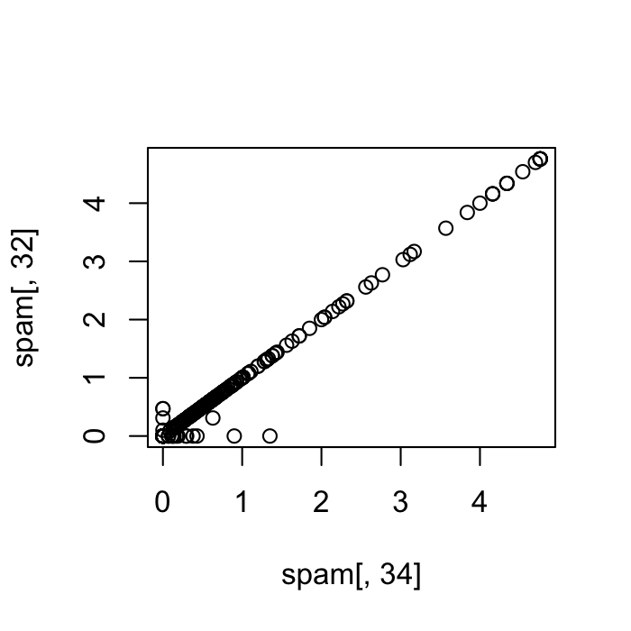

```r
plot(spam[,34],spam[,32])
```

We’d like to combine those two variables into a single variable.

## Basic PCA idea

- We might not need every predictor
- A weighted combination of predictors might be better
- We should pick this combination to capture the “most information” possible
- Benefits
- Reduced number of predictors
- Reduced noise (due to averaging)

## We could rotate the plot

$X = 0.71 \times {\rm num 415} + 0.71 \times {\rm num857}$

$Y = 0.71 \times {\rm num 415} - 0.71 \times {\rm num857}$

So $X$ is the sum of the two variables, and $Y$ is the difference of the two variables.

(And the factor of 0.71 seems to be scaling $Y$.)

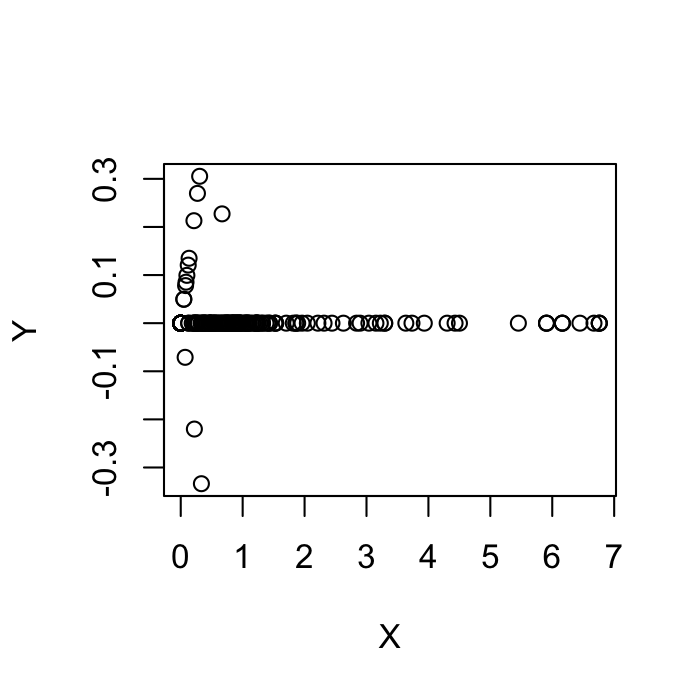

```r
X <- 0.71*training$num415 + 0.71*training$num857
Y <- 0.71*training$num415 - 0.71*training$num857
plot(X,Y)
```

We can see that most of the variability is happening in the x-axis, and most of the points are clustered at 0 on the y-axis.

Adding the variables captures most of the information, and subtracting the variables captures much less information. The subracted combination is essentially noise.

If we use the sum of the variables, in this case, we’ll reduce the number of variables in our dataset, and we’ll have this combo variable with reduced noise.

## Related problems

You have multivariate variables $X_1,\ldots,X_n$ so $X_1 = (X_{11},\ldots,X_{1m})$

- Find a new set of multivariate variables that are uncorrelated and explain as much variance as possible.
- If you put all the variables together in one matrix, find the best matrix created with fewer variables (lower rank) that explains the original data.

The first goal is statistical and the second goal is data compression.

## Related solutions - PCA/SVD

**SVD – Singular Value Decomposition**

If $X$ is a matrix with each variable in a column and each observation in a row then the SVD is a “matrix decomposition”

$X = UDV^T$

where the columns of $U$ are orthogonal (left singular vectors), the columns of $V$ are orthogonal (right singluar vectors) and $D$ is a diagonal matrix (singular values).

**PCA**

The principal components are equal to the right singular values if you first scale (subtract the mean, divide by the standard deviation) the variables.

## Principal components in R - prcomp

Here we use the `prcomp()` function from the stats package to show how to easily accomplish what we just did.

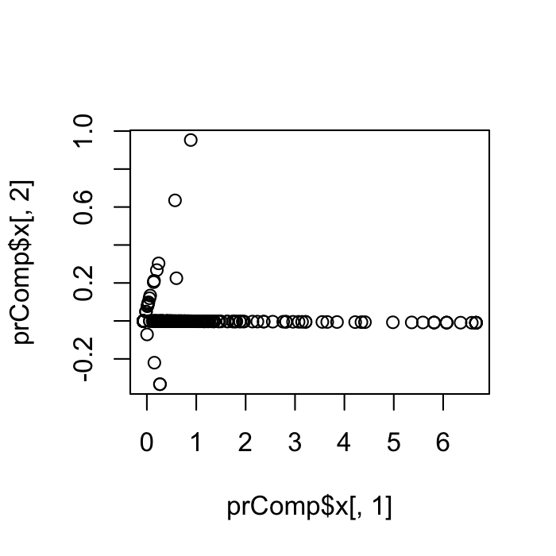

```r
smallSpam <- spam[,c(34,32)]
prComp <- prcomp(smallSpam)
plot(prComp$x[,1],prComp$x[,2])
```

- The first principle component is similar to the addition of the variables.
- The second principle component is similar to the subtraction of the variables.

However, principle components analysis can be performed on many variables at once!

## Principal components in R - prcomp

The rotation matrix shows how each principle component was summed.

```r
prComp$rotation
```

```
          PC1     PC2
num415 0.7081  0.7061
num857 0.7061 -0.7081
```

- PC1: We can see that num415 was scaled by 0.708 and then added to num857, which was scaled by 0.706.
- PC2: The variables were scaled oppositely and subtracted.

The principle components tell us that the most variability is explained by adding the two variables, and the second most variability is explained by subtracting the two.

I imagine that more variables would result in more PCs:

```r
smallSpam <- spam[,c(34,32,40)]
prComp3 <- prcomp(smallSpam)
prComp3$rotation
```

```
          PC1     PC2       PC3
num415 0.5753 -0.4178 -0.703226
num857 0.5743 -0.4059  0.710937
direct 0.5824  0.8129 -0.006414
```

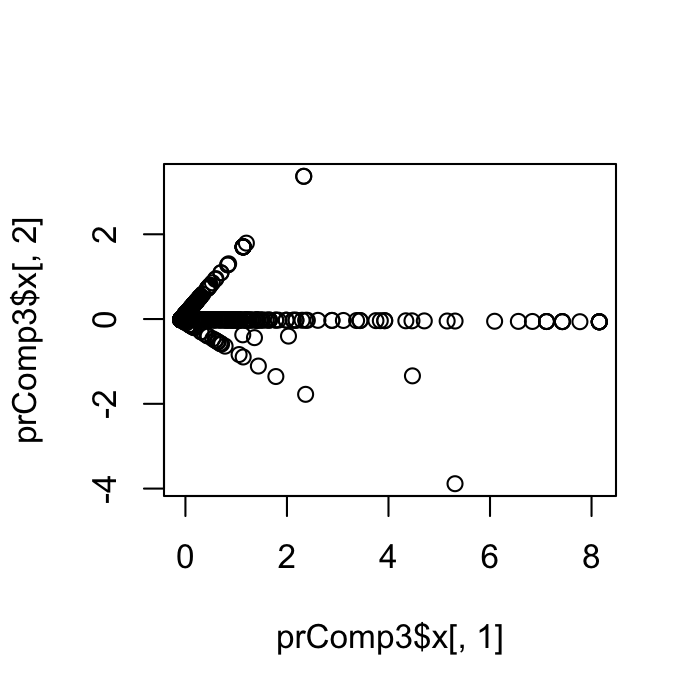

```r
plot(prComp3$x[,1],prComp3$x[,2])
```

## PCA on SPAM data

Let’s perform PCA on many variables.

First, we’ll sort the output variable into colors (red=spam, black=ham).

Then we’ll perform a `prcomp()` on the entire dataset. We’re applying a log10 and added 1 to everything in order to make the data look more gaussian because some of the variables are skewed. We often have to do that for PCA to look sensible.

Then we plot the first two principle components.

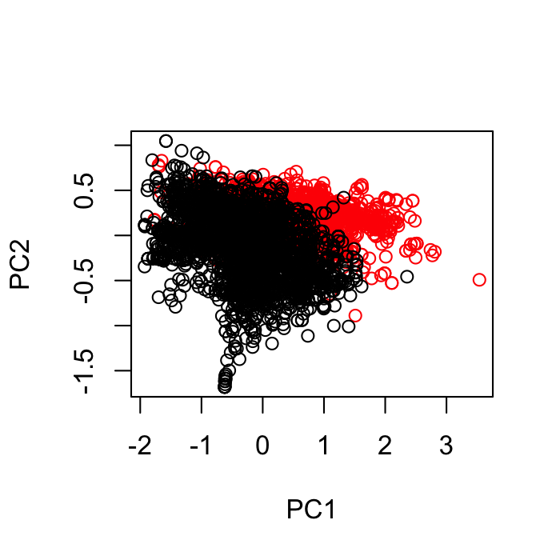

```r
typeColor <- ((spam$type=="spam")*1 + 1)
prComp <- prcomp(log10(spam[,-58]+1))
plot(prComp$x[,1],prComp$x[,2],col=typeColor,xlab="PC1",ylab="PC2")
```

PC1 is no longer a simple addition of two variables, but a very complicated combination of all the variables that explains the most variation of the data.

PC2 is the combination that explains the second most variation of the data (and so on).

In the plot, each circle is a single observation, and the red ones are spam.

Looking at the PC1 axis, we can see a good separation between spam and non-spam, in that the spam points tend to have a higher value of PC1.

## PCA with caret

We can also do PCA with the caret package by using the ‘method’ parameter in the `preProcess()` function to create a preprocess object (using the dataset). We can then apply the preprocess object to the `predict()` function (again, using the dataset) to get our principal components. (The number of PCs was chosen in the `preprocess()` function.)

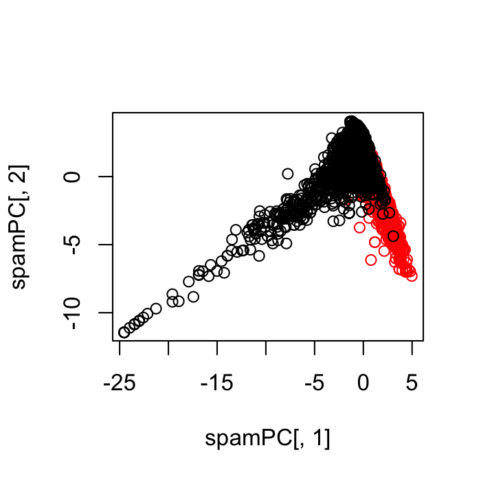

```r
preProc <- preProcess(log10(spam[,-58]+1),method="pca",pcaComp=2)
spamPC <- predict(preProc,log10(spam[,-58]+1))
plot(spamPC[,1],spamPC[,2],col=typeColor)
```

## Preprocessing with PCA

Here we fit a model with the principal components. Notice we don’t use the full training set for the model, but rather just the principle components of the training set.

```r
preProc <- preProcess(log10(training[,-58]+1),method="pca",pcaComp=2)
trainPC <- predict(preProc,log10(training[,-58]+1))
modelFit <- train(training$type ~ .,method="glm",data=trainPC)
```

## Preprocessing with PCA

For the test set, of course, we must use the same preprocess object (‘preProc’) that we created from the training set.

```r
testPC <- predict(preProc,log10(testing[,-58]+1))
confusionMatrix(testing$type,predict(modelFit,testPC))
```

```
Confusion Matrix and Statistics

          Reference
Prediction nonspam spam
   nonspam     657   40
   spam         73  380

               Accuracy : 0.902
                 95% CI : (0.883, 0.918)
    No Information Rate : 0.635
    P-Value [Acc > NIR] : < 2e-16

                  Kappa : 0.792
 Mcnemar's Test P-Value : 0.00261

            Sensitivity : 0.900
            Specificity : 0.905
         Pos Pred Value : 0.943
         Neg Pred Value : 0.839
             Prevalence : 0.635
         Detection Rate : 0.571
   Detection Prevalence : 0.606
      Balanced Accuracy : 0.902

       'Positive' Class : nonspam
```

We’ve just acheived a 90% accuracy with only 2 variables (our two principle components) instead of the 57 variables in the dataset!

## Alternative (sets # of PCs)

Here is a more compact way of writing that code. We’re building the predict function right into the `train()` function (from caret). We’ve passed it the ‘training’ subset and the preprocess type ‘pca’. Then we can use that model fit to predict the test set (‘testing’).

```r
modelFit <- train(training$type ~ .,method="glm",preProcess="pca",data=training)
confusionMatrix(testing$type,predict(modelFit,testing))
```

```
Confusion Matrix and Statistics

          Reference
Prediction nonspam spam
   nonspam     669   28
   spam         59  394

               Accuracy : 0.924
                 95% CI : (0.908, 0.939)
    No Information Rate : 0.633
    P-Value [Acc > NIR] : <2e-16

                  Kappa : 0.84
 Mcnemar's Test P-Value : 0.0013

            Sensitivity : 0.919
            Specificity : 0.934
         Pos Pred Value : 0.960
         Neg Pred Value : 0.870
             Prevalence : 0.633
         Detection Rate : 0.582
   Detection Prevalence : 0.606
      Balanced Accuracy : 0.926

       'Positive' Class : nonspam
```

## Final thoughts on PCs

- Most useful for linear-type models
- Can make it harder to interpret predictors
- Watch out for outliers!
- Transform first (with logs/Box Cox)
- Plot predictors to identify problems
- For more info see
- Exploratory Data Analysis
- [Elements of Statistical Learning](http://statweb.stanford.edu/~tibs/ElemStatLearn/)